# Project1

Marta Pałuba, Emilia Pompe, Małgorzata Pujszo

Linear models with fixed and random effects

Loading required libraries

```r
library(MASS)
library(dplyr)
library(lawstat)
library(agricolae)
```

# Changing the data

```r
load("expression.cb1.rda")
load("expression.cb2.rda")
load("clinical.cb.rda")
```

Let’s see what our data looks like.

```r
head(expression.cb1[,1:5])
```

```
##        Sample TCGA.AR.A1AH.01 TCGA.A5.A0GI.01 TCGA.BP.4165.01
## 1 ?|100133144        0.873126        1.160000              NA
## 2 ?|100134869       -0.380000       -0.332584           -1.27
## 3     ?|10357        0.220000        1.112895           -0.39
## 4     ?|10431        1.360000        0.119982            0.09
## 5    ?|155060       -0.030000        2.491257            0.63
## 6    ?|390284       -0.060000        1.156183           -0.03
##   TCGA.CJ.4876.01
## 1       -0.896874
## 2              NA
## 3       -0.300000
## 4        0.510000
## 5       -0.950000
## 6        0.730000
```

```r
head(expression.cb2[,1:5])
```

```
##        Sample TCGA.AR.A1AH.01 TCGA.A5.A0GI.01 TCGA.BP.4165.01
## 8001 LOC92249        1.170000        0.258267        0.700000
## 8002 LOC92659        0.828500        1.256706       -1.471500
## 8003 LOC92973       -0.010000        1.418838        0.670000
## 8004 LOC93432              NA              NA              NA
## 8005 LOC93622        0.310000        0.327851       -0.440000
## 8006 LOC96610       -1.882837       -0.527163       -1.792837
##      TCGA.CJ.4876.01
## 8001        0.920000
## 8002       -0.521500
## 8003        0.780000
## 8004              NA
## 8005        0.050000
## 8006        0.777163
```

```r
head(clinical.cb[,1:6])
```

```
##          sampleID X_EVENT   X_INTEGRATION X_OS X_OS_IND
## 1 TCGA-02-0001-01       1 TCGA-02-0001-01  358        1
## 2 TCGA-02-0003-01       1 TCGA-02-0003-01  144        1
## 3 TCGA-02-0004-01       1 TCGA-02-0004-01  345        1
## 4 TCGA-02-0006-01       1 TCGA-02-0006-01  558        1
## 5 TCGA-02-0007-01       1 TCGA-02-0007-01  705        1
## 6 TCGA-02-0009-01       1 TCGA-02-0009-01  322        1
##   X_PANCAN_CNA_PANCAN_K8
## 1                   High
## 2                    GBM
## 3                    GBM
## 4                    GBM
## 5                    GBM
## 6                    GBM
```

Firstly, we want to merge expression.cb1, expression.cb2 and clinical.cb , so we have one big data frame that we can work on. For that we have to:

- combine expression.cb1 and expression.cb2

```r
expression <-rbind(expression.cb1, expression.cb2)
```

- change “.” to “-” in names of the columns, so they match the names in clinical.cb

```r
colnames(expression)<-gsub(".","-", colnames(expression), fixed=TRUE)
```

- transpose data to have genes in columns and patient IDs in raws and name corresponding columns/raws

```r
trial <-t(expression[,-1])
trial<- as.data.frame(trial)
colnames(trial) <- expression[,1]
trial$sampleID <- rownames(trial)
```

- merge clinical.cb with changed data from expression

```r
dataset<-merge(trial, clinical.cb, by="sampleID")
```

Let’s see how it looks now.

```r
head(dataset[,1:6])
```

```
##          sampleID ?|100133144 ?|100134869   ?|10357   ?|10431  ?|155060
## 1 TCGA-02-0047-01   -1.686874   -0.573000 -0.986000 -0.028000  0.534000
## 2 TCGA-02-0055-01          NA    0.642000 -1.788000 -0.029000  0.010000
## 3 TCGA-02-2483-01   -1.747874    0.471000 -0.845000  0.450000 -0.252000
## 4 TCGA-02-2485-01    0.693126    0.573000 -0.239000 -0.943000  1.376000
## 5 TCGA-02-2486-01   -0.831874   -1.065000 -0.793000 -0.726000  0.780000
## 6 TCGA-04-1348-01   -0.080000    1.037416 -2.737105  0.489982  0.371257
```

Now we have something to work on.

# Filter the data

```r
table(dataset$X_cohort)
```

```
##
##                          TCGA Acute Myeloid Leukemia
##                                                  173
##                                  TCGA Bladder Cancer
##                                                  122
##                                   TCGA Breast Cancer
##                                                  840
##                                    TCGA Colon Cancer
##                                                  190
##                             TCGA Endometrioid Cancer
##                                                  370
## TCGA Formalin Fixed Paraffin-Embedded Pilot Phase II
##                                                   12
##                                    TCGA Glioblastoma
##                                                  166
##                            TCGA Head and Neck Cancer
##                                                  303
##                     TCGA Kidney Clear Cell Carcinoma
##                                                  476
##                             TCGA Lung Adenocarcinoma
##                                                  352
##                    TCGA Lung Squamous Cell Carcinoma
##                                                  258
##                                  TCGA Ovarian Cancer
##                                                  265
##                                   TCGA Rectal Cancer
##                                                   72
```

As we can observe we have 13 types of cancer, but one has only 12 observation. It’s not enough to conclude anything from it, so we decide to remove it.

```r
dataset <- filter(dataset, X_cohort!="TCGA Formalin Fixed Paraffin-Embedded Pilot Phase II")
dataset$X_cohort<-factor(dataset$X_cohort)
```

To improve the model we also decide to remove the values of any data points which lie beyond the extremes of the whiskers in boxplot. To do that we use the function called boxplot.stats

```r
f<-function (x) {
  x[x %in% boxplot.stats(x)$out]<-NA
  x
}
dataset[,2:16116]<-apply(dataset[,2:16116], 2, f)
```

# Assumptions

To find genes that differ between cancer types significantly, we would like to use ANOVA. But ANOVA requires normality of residuals and homogeneity of variance. To check if residuals have normal distribiution we used Shapiro-Wilk test. To test the homogeneity of variance we use Levene test.

```r
shapiro_coeff1 <- rep(NA, times=16115)
shapiro_coeff2 <- rep(NA, times=16115)
levene1 <- rep(NA, times=16115)
levene2 <- rep(NA, times=16115)
```

We’re using 2 different models:

- the standard one - just using lm-function
- after the Box Cox transformation

Now, we are creating a huge loop going through each gene.

```r
threshold <- 20
n <- 10
set.seed(7)
for(i in 1:16116){
  y <- dataset[,i] + abs(min(dataset[,i], na.rm=TRUE)) +0.01
  d <- data.frame(y=y[!(is.na(y))], x=dataset$X_cohort[!(is.na(y))])
  bad <- names(which(table(d$x) < threshold))
  d <- filter(d, !(x %in% bad))
  d$x <- factor(d$x)
  p.values.levene <- rep(NA, times=n )
  p.values.shapiro <- rep(NA, times=n )
  for (k in 1:n){
    testy<-tapply(d$y, d$x, function(x) {
      sample(x, size=50, replace = TRUE)})
    a<-data.frame(nrow=50, ncol=2)
    d.equal<-c()
    for (j in 1:length(testy)) {
      a <- cbind(as.numeric(testy[[j]]), names(testy)[j])
      d.equal <- as.data.frame(rbind(d.equal, a))
    }
    colnames(d.equal)<-c("y","x")
    d.equal$y<-as.numeric(as.character(d.equal$y))
    model <- lm(y~x, data=d.equal)
    assign(paste0("model",k), model)
    p.values.levene[k] <- levene.test(d.equal$y, d.equal$x)$p.value
  }
  if (median(p.values.levene)>0.01){
    p.values.shapiro <- sapply(1:n, function(number){
      model <-get(paste0("model",number))
      return(shapiro.test(rstandard(model))$p.value)
    })
  }
  median.shapiro <- median(p.values.shapiro)
  shapiro_coeff1[i-1] <- median.shapiro
  levene1[i-1] <- median(p.values.levene)
  if (is.na(median.shapiro)  | median.shapiro<0.01){
    for (k in 1:n) {
      #print(k)
      tmp <- boxcox(get(paste0("model",k)), lambda=seq(-2,5,0.2), plotit=FALSE)
      wsp <- tmp$x[which.max(tmp$y)]
      d.equal <- get(paste0("model",k))$model
      if(wsp<=0.05){
        model <- lm(log(y)~x, data = d.equal)
        p.values.levene[k] <- levene.test(log(d.equal$y), d.equal$x)$p.value
      }
      else {
        model <- lm((y^wsp)~x, data = d.equal)
        p.values.levene[k] <- levene.test((d.equal$y)^wsp, d.equal$x)$p.value
      }
      assign(paste0("model",k), model)
    }
    if (median(p.values.levene)>0.01){
      p.values.shapiro <- sapply(1:n, function(number){
        model <-get(paste0("model",number))
        return(shapiro.test(rstandard(model))$p.value)
      })
    }
    shapiro_coeff2[i-1] <- median(p.values.shapiro)
    levene2[i-1] <- median(p.values.levene)
    }
}
```

Let’s see what we are doing step by step.

In every column we are temporarily removing the types of cancer that have less than 20 observations for given gene.

```r
  y <- dataset[,i] + abs(min(dataset[,i], na.rm=TRUE)) +0.01
  d <- data.frame(y=y[!(is.na(y))], x=dataset$X_cohort[!(is.na(y))])
  bad <- names(which(table(d$x) < threshold))
  d <- filter(d, !(x %in% bad))
  d$x <- factor(d$x)
```

The next problem that we are trying to solve is that the Levene test is very sensitive for non-equal size of groups. Our idea is to take random sample of size 50 and repeat this step 10 times in order to get more reliable results.

```r
 for (k in 1:n){
    testy<-tapply(d$y, d$x, function(x) {
      sample(x, size=50, replace = TRUE)})
    a<-data.frame(nrow=50, ncol=2)
    d.equal<-c()
    for (j in 1:length(testy)) {
      a <- cbind(as.numeric(testy[[j]]), names(testy)[j])
      d.equal <- as.data.frame(rbind(d.equal, a))
    }
    colnames(d.equal)<-c("y","x")
    d.equal$y<-as.numeric(as.character(d.equal$y))
    model <- lm(y~x, data=d.equal)
    assign(paste0("model",k), model)
    p.values.levene[k] <- levene.test(d.equal$y, d.equal$x)$p.value
  }
```

Now when the median of p-values is greater than significance level (0.01) we are performing Shapiro test.

```r
if (median(p.values.levene)>0.01){
    p.values.shapiro <- sapply(1:n, function(number){
      model <-get(paste0("model",number))
      return(shapiro.test(rstandard(model))$p.value)
    })
  }
```

If the medians of p-values of Levene test or Shapiro test are less than 0.01 we are making Box-Cox transformation and repeat our reasoning for transformated variables.

If the Levene test is rejecting null hypothesis for both models, we are infering that such genes differ significantly. Otherwise we are performing ANOVA test or Kruskal test (when Shapiro test fails) - for model giving better results.

# ANOVA and Kruskal test

ANOVA test for better model:

```r
load("test.results.both.RData")
threshold<-20
anova.data.frame <- as.data.frame(rbind(
  cbind(which(test.results.both$shapiro_coeff1>=0.01), rep(1, times=length(which(test.results.both$shapiro_coeff1>=0.01)))),
  cbind(which(test.results.both$shapiro_coeff2>=0.01), rep(2, times=length(which(test.results.both$shapiro_coeff2>=0.01))))))

anova.data.frame[,1] <- anova.data.frame[,1] + 1
anova.data.frame$p.value <- rep(NA, times = nrow(anova.data.frame))

for(k in 1:nrow(anova.data.frame)){
  i <- anova.data.frame[k,1]
  y <- dataset[,i] + abs(min(dataset[,i], na.rm=TRUE)) +0.01
  d <- data.frame(y=y[!(is.na(y))], x=dataset$X_cohort[!(is.na(y))])
  bad <- names(which(table(d$x) < threshold))
  d <- filter(d, !(x %in% bad))
  d$x <- factor(d$x)

  model <- lm(y~x, data=d)
  if (anova.data.frame[k,2]==1) {
    anova.data.frame[k,3] <- anova(model)[1,5]
  }
  else {
    tmp <- boxcox(model, lambda=seq(-2,5,0.2), plotit=FALSE)
    wsp <- tmp$x[which.max(tmp$y)]
    if(wsp<=0.05){
      model1 <- lm(log(y)~x, data = d)
    }

    else {
      model1 <- lm((y^wsp)~x, data = d)
    }
    anova.data.frame[k,3] <- anova(model1)[1,5]
  }
}
```

Kruskal test for better model. Here we are making one modification: firstly we are transforming y to a normal distribution and check its normality using Shapiro test. If it is working, we are again performing ANOVA, if not we are perfoming Kruskal on better model (original or after Box-Cox).

```r
kruskal.data.frame <- as.data.frame(rbind(cbind(which(test.results.both$shapiro_coeff1<0.01), rep(1, times=length(which(test.results.both$shapiro_coeff1<0.01)))),
                                          cbind(which(test.results.both$shapiro_coeff2<0.01), rep(2, times=length(which(test.results.both$shapiro_coeff2<0.01))))))

kruskal.data.frame[,1] <- kruskal.data.frame[,1] + 1
kruskal.data.frame$p.value <- rep(NA, times = nrow(kruskal.data.frame))

for(k in 1:nrow(kruskal.data.frame)){
  i <- kruskal.data.frame[k,1]

  y <- dataset[,i] + abs(min(dataset[,i], na.rm=TRUE)) +0.01
  d <- data.frame(y=y[!(is.na(y))], x=dataset$X_cohort[!(is.na(y))])
  bad <- names(which(table(d$x) < threshold))
  d <- filter(d, !(x %in% bad))
  d$x <- factor(d$x)

  # transforming y to normal distribution
  d$y.new <- qnorm(ecdf(d$y)(d$y)-1/(2*length(y)))
  model3 <- lm(y.new~x, data = d)
  if((shapiro.test(rstandard(model3))$p.value >= 0.01) & levene.test(d$y.new, d$x)$p.value >= 0.01){
    kruskal.data.frame[k,3] <- anova(model3)[1,5]
    kruskal.data.frame[k,2] <- 3
  } else {

    if (kruskal.data.frame[k,2]==1) {
      kruskal.data.frame[k,3] <- kruskal.test(y~x, data=d)$p.value
    }
    else {
      model <- lm(y~x, data=d)
      tmp <- boxcox(model, lambda=seq(-2,5,0.2), plotit=FALSE)
      wsp <- tmp$x[which.max(tmp$y)]
      if(wsp<=0.05){
        d$y <- log(d$y)
      }
      else {
        d$y <- (d$y)^wsp
      }
      kruskal.data.frame[k,3] <- kruskal.test(y~x, data=d)$p.value
    }
  }
}
```

# Results

anova.kruskal is a data frame consisting of p-values of ANOVA and Kruskal tests.

```r
anova.data.frame$which.test <- rep("anova", times=nrow(anova.data.frame))
kruskal.data.frame$which.test <- sapply(kruskal.data.frame[,2], function(nr) ifelse(nr==3, "anova", "kruskal"))

anova.kruskal <- rbind(anova.data.frame, kruskal.data.frame)
colnames(anova.kruskal)[1:2] <- c("gene.number", "better.model")
```

Let’s take a look at our results. It turned out that very few genes were not significant in our analysis.

```r
head(anova.kruskal, 10)
```

```
##    gene.number better.model       p.value which.test
## 1            5            1 6.204504e-251      anova
## 2           11            1 5.729442e-165      anova
## 3           18            1 3.472660e-240      anova
## 4           19            1  0.000000e+00      anova
## 5           22            1  0.000000e+00      anova
## 6           24            1  8.807227e-63      anova
## 7           27            1 8.209019e-245      anova
## 8           45            1  0.000000e+00      anova
## 9           52            1 4.811788e-242      anova
## 10          53            1 2.178258e-224      anova
```

```r
table(anova.kruskal$p.value>0.01)
```

```
##
## FALSE  TRUE
##  5800    18
```

```r
table(anova.kruskal$p.value>0.005)
```

```
##
## FALSE  TRUE
##  5797    21
```

We would like to show one detailed example of our analysis, for the gene number 1201.

```r
anova.kruskal[which(anova.kruskal$gene.number==1201),]
```

```
##     gene.number better.model       p.value which.test
## 212        1201            1 6.616362e-265      anova
```

```r
i <- 1201
colnames(dataset)[i]
```

```
## [1] "BCAR1"
```

As before, we needed to throw away the levels with less than 20 observations. Note that here we did not need transform the data to be positive, as no Box-Cox transformations are needed.

```r
y <- dataset[,i]
d <- data.frame(y=y[!(is.na(y))], x=dataset$X_cohort[!(is.na(y))])
bad <- names(which(table(d$x) < threshold))
d <- filter(d, !(x %in% bad))
d$x <- factor(d$x)

table(d$x)
```

```
##
##               TCGA Bladder Cancer                TCGA Breast Cancer
##                               122                               826
##                 TCGA Colon Cancer          TCGA Endometrioid Cancer
##                               184                               365
##                 TCGA Glioblastoma         TCGA Head and Neck Cancer
##                               166                               302
##  TCGA Kidney Clear Cell Carcinoma          TCGA Lung Adenocarcinoma
##                               471                               347
## TCGA Lung Squamous Cell Carcinoma               TCGA Ovarian Cancer
##                               256                               264
##                TCGA Rectal Cancer
##                                70
```

11 groups were taken into consideration. The proper model for this gene was the one without any transformations.

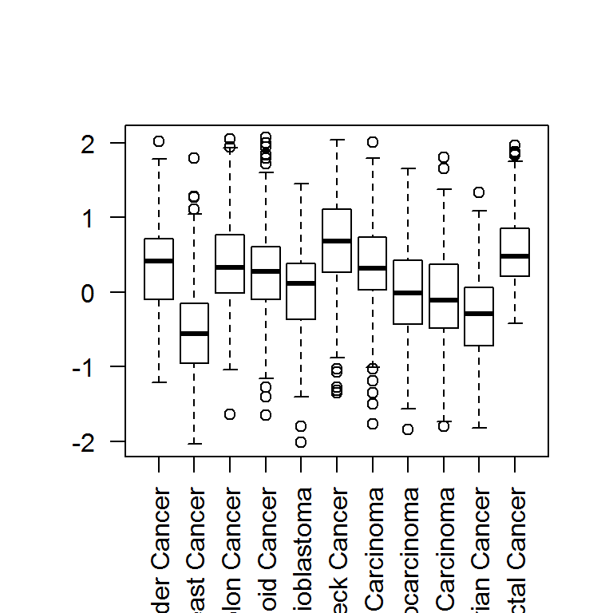

```r
boxplot(y~x, data=d, las=2)
```

```r
model <- lm(y~x, data = d)
```

Let us check the crucial assumption of normality:

```r
shapiro.test(rstandard(model))
```

```
##
##  Shapiro-Wilk normality test
##
## data:  rstandard(model)
## W = 0.9993, p-value = 0.2234
```

When our model has the normal distribution, we can use Bartlett test instead of Levene test. It’s slightly better and doesn’t need equal groups, but it is more sensitive for asumption of normality.

```r
bartlett.test(d$y~d$x)
```

```
##
##  Bartlett test of homogeneity of variances
##
## data:  d$y by d$x
## Bartlett's K-squared = 14.7819, df = 10, p-value = 0.1402
```

Now we can do ANOVA:

```r
anova(model)
```

```
## Analysis of Variance Table
##
## Response: y
##             Df Sum Sq Mean Sq F value    Pr(>F)
## x           10  569.1  56.910  152.91 < 2.2e-16 ***
## Residuals 3362 1251.2   0.372
## ---
## Signif. codes:  0 '***' 0.001 '**' 0.01 '*' 0.05 '.' 0.1 ' ' 1
```

The result of the ANOVA test shows that there are significant differences in the model.

Let us also take a look at the diagnostic plots

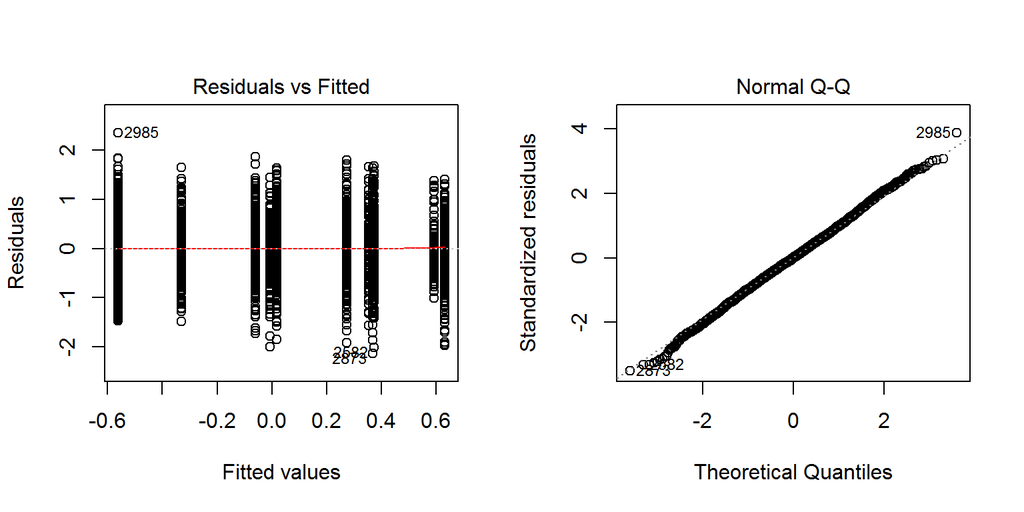

```r
par(mfrow=c(1,2))
plot(model, which=1:2)
```

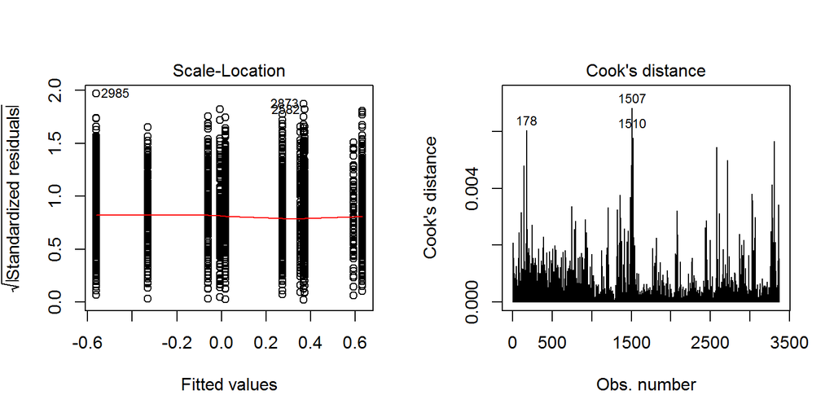

```r
par(mfrow=c(1,2))
plot(model, which=3:4)
```

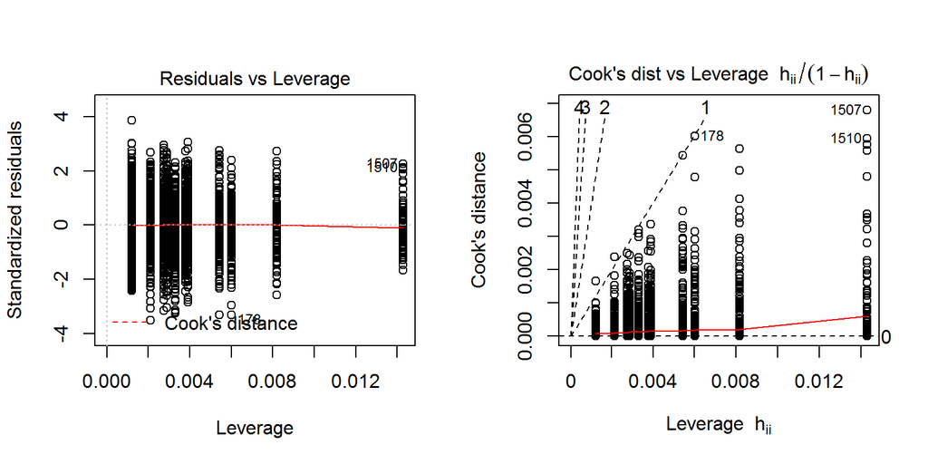

```r
par(mfrow=c(1,2))
plot(model, which=5:6)
```

The post hoc analysis indicated which levels were significantly different. Note that the results of these two test are slightly different.

```r
LSD.test(aov(y~x, data=d), "x", p.adj="holm", console = TRUE)
```

```
##
## Study: aov(y ~ x, data = d) ~ "x"
##
## LSD t Test for y
## P value adjustment method: holm
##
## Mean Square Error:  0.3721743
##
## x,  means and individual ( 95 %) CI
##
##                                              y       std   r         LCL
## TCGA Bladder Cancer                0.354656066 0.6152366 122  0.24636372
## TCGA Breast Cancer                -0.563170315 0.6222475 826 -0.60478893
## TCGA Colon Cancer                  0.374891304 0.6377496 184  0.28671157
## TCGA Endometrioid Cancer           0.273068493 0.6027418 365  0.21046029
## TCGA Glioblastoma                 -0.005451084 0.5867533 166 -0.09828863
## TCGA Head and Neck Cancer          0.633131258 0.6253984 302  0.56430182
## TCGA Kidney Clear Cell Carcinoma   0.369522760 0.5489161 471  0.31440809
## TCGA Lung Adenocarcinoma           0.019330086 0.6391111 347 -0.04488143
## TCGA Lung Squamous Cell Carcinoma -0.060765937 0.6346622 256 -0.13552394
## TCGA Ovarian Cancer               -0.329318182 0.6019552 264 -0.40293478
## TCGA Rectal Cancer                 0.592571429 0.5880049  70  0.44960678
##                                           UCL      Min     Max
## TCGA Bladder Cancer                0.46294841 -1.21018 2.01982
## TCGA Breast Cancer                -0.52155170 -2.04018 1.79982
## TCGA Colon Cancer                  0.46307104 -1.64000 2.05000
## TCGA Endometrioid Cancer           0.33567670 -1.65000 2.07000
## TCGA Glioblastoma                  0.08738646 -2.01818 1.44782
## TCGA Head and Neck Cancer          0.70196069 -1.35018 2.03982
## TCGA Kidney Clear Cell Carcinoma   0.42463743 -1.77018 2.00982
## TCGA Lung Adenocarcinoma           0.08354161 -1.84018 1.65982
## TCGA Lung Squamous Cell Carcinoma  0.01399207 -1.80018 1.80982
## TCGA Ovarian Cancer               -0.25570159 -1.82000 1.33000
## TCGA Rectal Cancer                 0.73553608 -0.42000 1.97000
##
## alpha: 0.05 ; Df Error: 3362
## Critical Value of t: 3.320211
##
## Minimum difference changes for each comparison
##
## Means with the same letter are not significantly different.
##
## Groups, Treatments and means
## a     TCGA Head and Neck Cancer           0.6331
## ab    TCGA Rectal Cancer                  0.5926
## bc    TCGA Colon Cancer                   0.3749
## bc    TCGA Kidney Clear Cell Carcinoma    0.3695
## bc    TCGA Bladder Cancer                 0.3547
## c     TCGA Endometrioid Cancer            0.2731
## d     TCGA Lung Adenocarcinoma            0.01933
## d     TCGA Glioblastoma                   -0.005451
## d     TCGA Lung Squamous Cell Carcinoma   -0.06077
## e     TCGA Ovarian Cancer                 -0.3293
## f     TCGA Breast Cancer                  -0.5632
```

```r
scheffe.test(aov(y~x, data=d), "x", console = TRUE)
```

```
##
## Study: aov(y ~ x, data = d) ~ "x"
##
## Scheffe Test for y
##
## Mean Square Error  : 0.3721743
##
## x,  means
##
##                                              y       std   r      Min
## TCGA Bladder Cancer                0.354656066 0.6152366 122 -1.21018
## TCGA Breast Cancer                -0.563170315 0.6222475 826 -2.04018
## TCGA Colon Cancer                  0.374891304 0.6377496 184 -1.64000
## TCGA Endometrioid Cancer           0.273068493 0.6027418 365 -1.65000
## TCGA Glioblastoma                 -0.005451084 0.5867533 166 -2.01818
## TCGA Head and Neck Cancer          0.633131258 0.6253984 302 -1.35018
## TCGA Kidney Clear Cell Carcinoma   0.369522760 0.5489161 471 -1.77018
## TCGA Lung Adenocarcinoma           0.019330086 0.6391111 347 -1.84018
## TCGA Lung Squamous Cell Carcinoma -0.060765937 0.6346622 256 -1.80018
## TCGA Ovarian Cancer               -0.329318182 0.6019552 264 -1.82000
## TCGA Rectal Cancer                 0.592571429 0.5880049  70 -0.42000
##                                       Max
## TCGA Bladder Cancer               2.01982
## TCGA Breast Cancer                1.79982
## TCGA Colon Cancer                 2.05000
## TCGA Endometrioid Cancer          2.07000
## TCGA Glioblastoma                 1.44782
## TCGA Head and Neck Cancer         2.03982
## TCGA Kidney Clear Cell Carcinoma  2.00982
## TCGA Lung Adenocarcinoma          1.65982
## TCGA Lung Squamous Cell Carcinoma 1.80982
## TCGA Ovarian Cancer               1.33000
## TCGA Rectal Cancer                1.97000
##
## alpha: 0.05 ; Df Error: 3362
## Critical Value of F: 1.833511
##
## Harmonic Mean of Cell Sizes  204.0738
## Minimum Significant Difference: 0.2586047
##
## Means with the same letter are not significantly different.
##
## Groups, Treatments and means
## a     TCGA Head and Neck Cancer           0.6331
## ab    TCGA Rectal Cancer                  0.5926
## b     TCGA Colon Cancer                   0.3749
## b     TCGA Kidney Clear Cell Carcinoma    0.3695
## b     TCGA Bladder Cancer                 0.3547
## b     TCGA Endometrioid Cancer            0.2731
## c     TCGA Lung Adenocarcinoma            0.01933
## c     TCGA Glioblastoma                   -0.005451
## c     TCGA Lung Squamous Cell Carcinoma   -0.06077
## d     TCGA Ovarian Cancer                 -0.3293
## e     TCGA Breast Cancer                  -0.5632
```